# chap.1 pattern detection thresholds

Arthur de Grandpré

26 février 2019

# Context

This is an initial draft to the first chapter of my thesis about the resolution threshold of vegetation pattern detection by remote sensing tools.  
The main idea of this chapter is to:

Compute multiple *indicators* describing a pattern for various known patterns in a very high resolution remote sensing image, and then downsample the resolution and recompute the indicators.

# Test run

```r
rm(list=ls()) ; gc()
```

```
##           used (Mb) gc trigger (Mb) max used (Mb)
## Ncells  543841 29.1    1242998 66.4   621665 33.3
## Vcells 1023821  7.9    8388608 64.0  1601611 12.3
```

```r
library(sp)
library(raster)
library(rgdal)
library(SDMTools)
library(tidyverse)
```

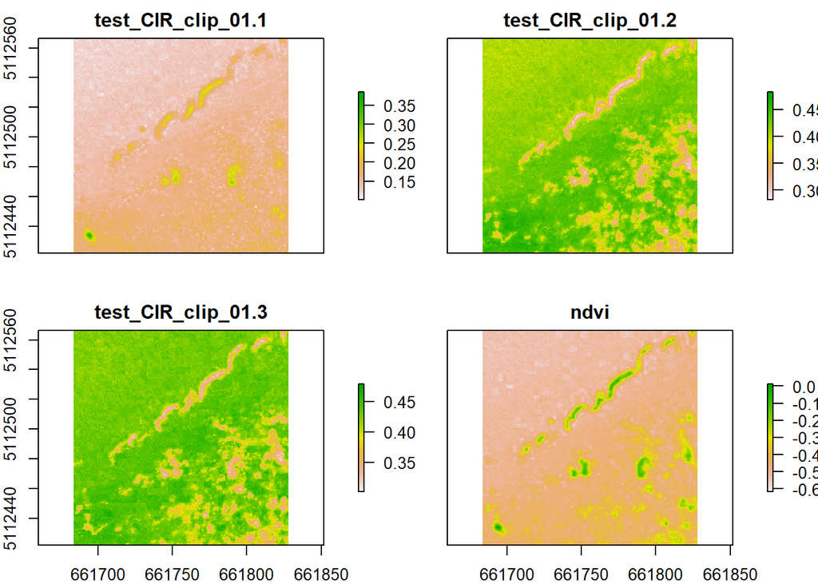

```r
### INITIAL SPECIFIC WRITING
r1=brick("data/ex1/test_CIR_clip_01.tif") # small subset of 2012 mosaic made in arcmap corresponding CRS is NAD83 UTM 18N
r1=r1/255 # this is to bring back the reflectance values to a 0-1 scale
r1$ndvi=(r1$test_CIR_clip_01.1-r1$test_CIR_clip_01.2)/(r1$test_CIR_clip_01.1+r1$test_CIR_clip_01.2) # this computes the normalized difference vegetation index when band 1 is NIR, band 2 is RED, band 3 is GREEN
###

### GENERALIZED EQUIVALENT
images_dir = "data/ex1" # directory of test image(s)
images = dir(images_dir, pattern = ".tif$") # available rasters
r1=brick(paste0(images_dir,"/",images[1])) # small subset of 2012 mosaic made in arcmap corresponding CRS is NAD83 UTM 18N
r1=r1/255
r1$ndvi=(r1[[1]]-r1[[2]])/(r1[[1]]+r1[[2]]) # this computes the normalized difference vegetation index when band 1 is NIR, band 2 is RED, band 3 is GREEN
###

plot(r1) # we see the 3 bands and the ndvi index
```

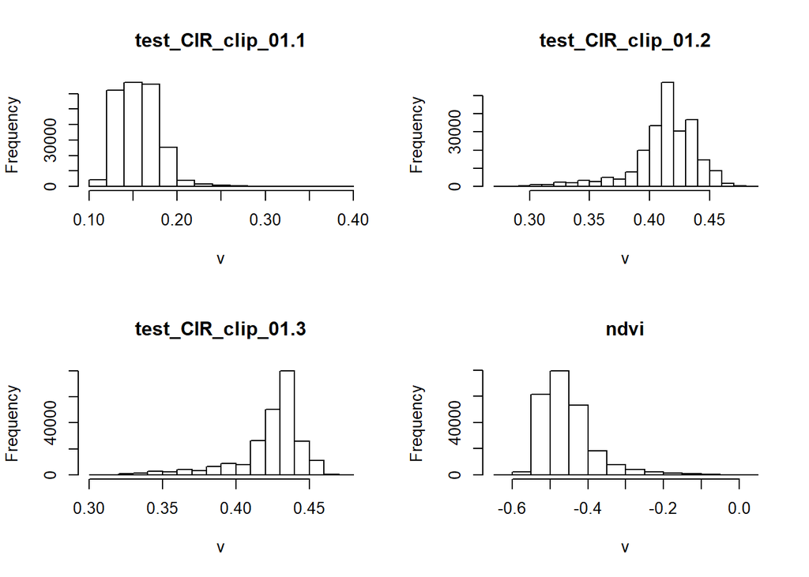

```r
hist(r1) # we see the value distribution of every band
```

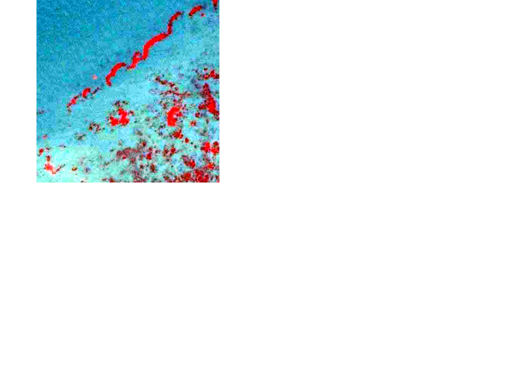

```r
plotRGB(r1, scale=1, stretch="lin") # this is as CIR imagery (NIR - Red - Green)
```

This is the initial test rasterbrick that will be used for this exercise. it contains 4 bands: NIR, RED, GREEN and NDVI

## landscape metrics

The next step is to obtain a binary vegetation map, here based on simple tresholds (should be changed according to the image used)

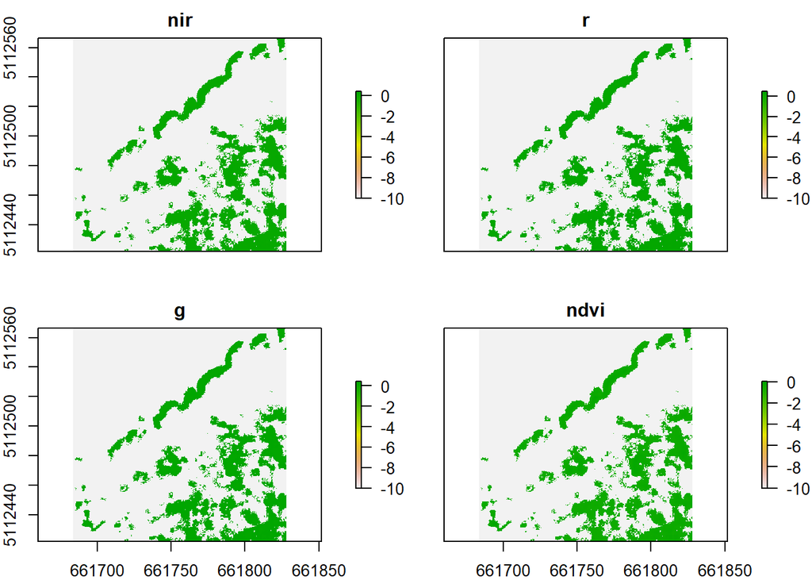

```r
r2=r1 # to work on a different raster than the original
names(r2)=c("nir","r","g","ndvi") # to set layer names
r2[r2$ndvi<(-0.45) | r2$g>0.42]=-10 # a specific mask (won't be easy to generalize)
plot(r2) # every bands were subsetted by the mask
```

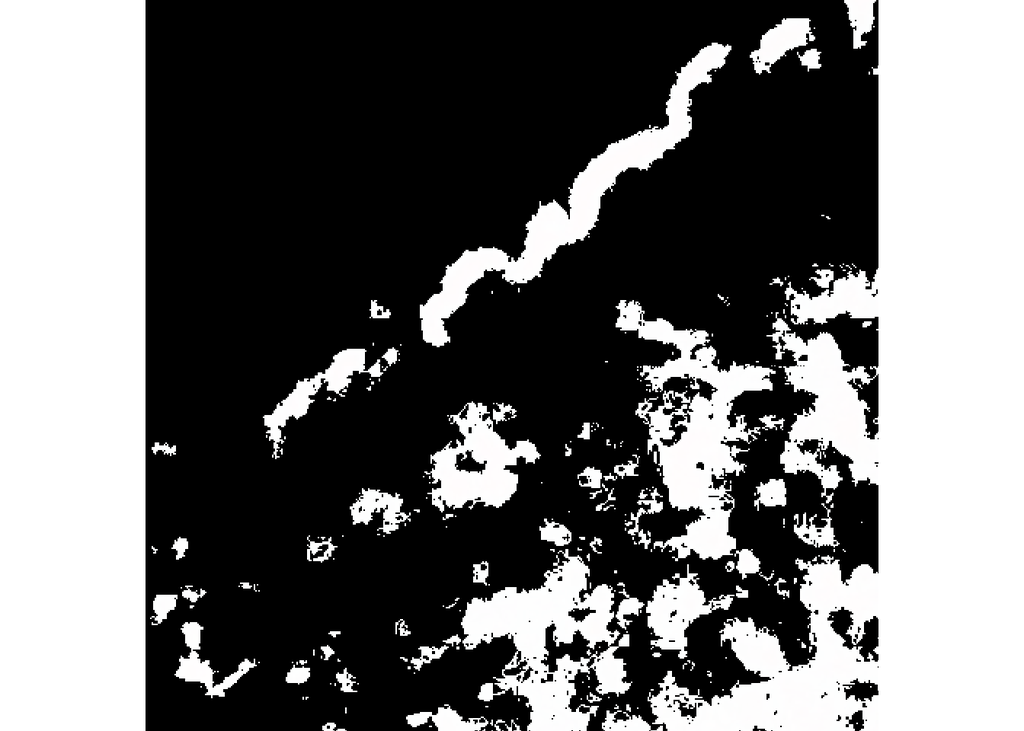

```r
plotRGB(r2, scale=1, stretch="lin") #this is CIR imagery (NIR Red Green)
```

This new raster will be converted to binary values in the next step

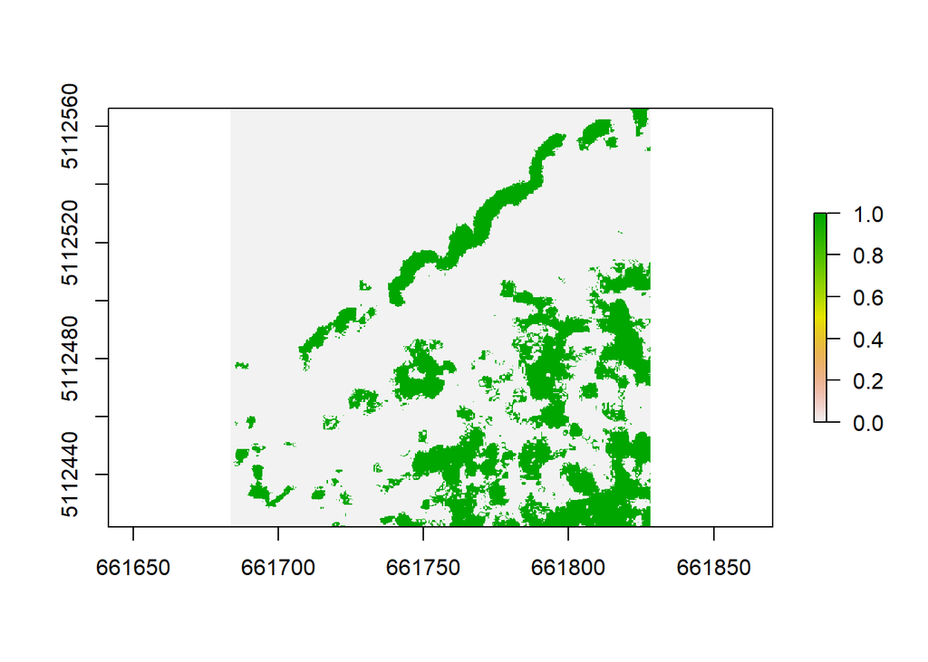

```r
r3=r2$ndvi # Since we only need a single band
r3[r3>(-10)]=1 ; r3[r3==(-10)]=0 # everything assigned to -10 is now 0, and everything else is now 1
plot(r3)
```

This is the binary raster of vegetation cover. From this raster, let’s create polygons in order to obtain our patch metrics

```r
p=rasterToPolygons(r3, dissolve=T) # very slow, should look into python & polygonizeR
p=disaggregate(p)
```

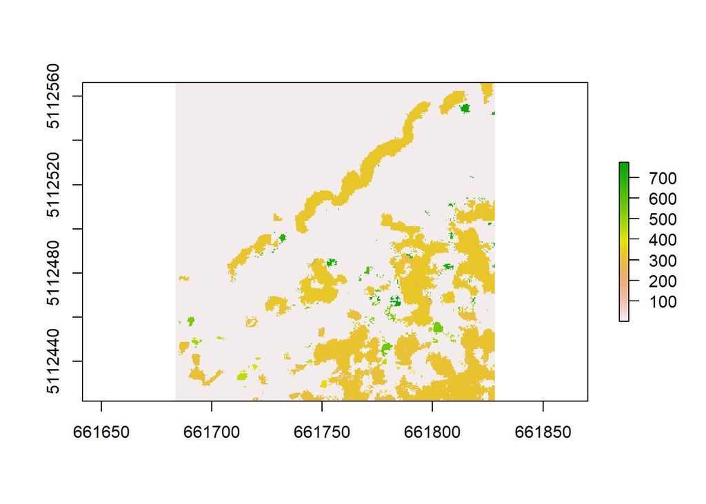

```r
pr=rasterize(p,r3) # this creates a raster of p, based on the configuration of r3
plot(pr) # pr contains a raster of 774 patches of different codes
```

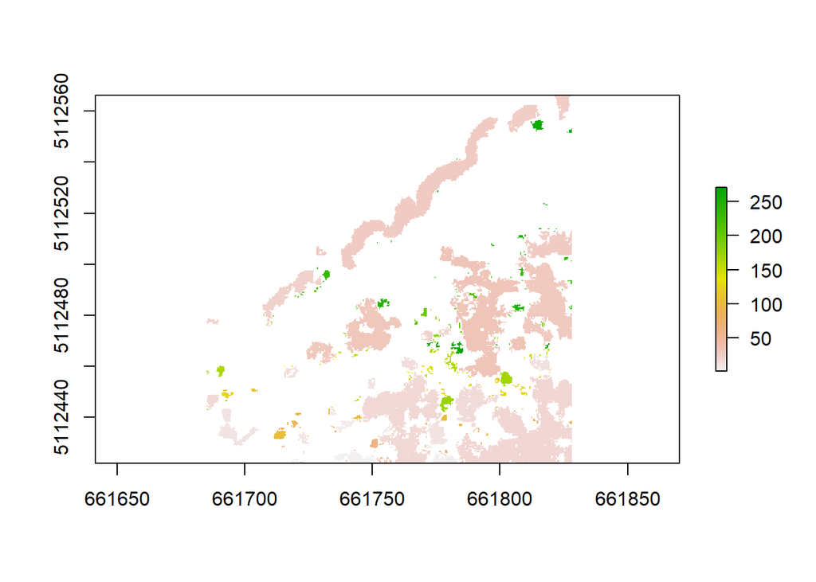

```r
ps=PatchStat(pr) # if we obtain PatchStats from this raster, it creates a statistic for every single patches, including single pixels and including non vegetation

p@data$patchID=rownames(p@data) # adds a column in p that contains the rownames (polygonID)
p2=merge(p,ps, by="patchID") # adds the statistics to the polygons so they contain their information

p2=p2[complete.cases(p2@data),] # removes polygons that do not have all information (single pixels)
rc=rasterize(p2, r3, field="ndvi") # forms a new raster without the single pixels

pv=p2[p2@data$ndvi==1,] # keeps only vegetation pixels
pr2=rasterize(pv, r3) # creates a new raster where only vegetated patches with more than 1 pixel exist
plot(pr2)
```

```r
PS = PatchStat(pr2) # calculates statistics for every patches
CS = ClassStat(rc) # calculates statistics for the whole vegetation class
```

We now have patch and class stats for our data

```r
as.tibble(PS)
```

```
## # A tibble: 271 x 12
##    patchID n.cell n.core.cell n.edges.perimet~ n.edges.internal  area core.area
##      <int>  <int>       <int>            <int>            <int> <dbl>     <dbl>
##  1       1     39           3               40              116    39         3
##  2       2    463         286              194             1658   463       286
##  3       3    271         139              136              948   271       139
##  4       4     26           0               40               64    26         0
##  5       5    157          41              132              496   157        41
##  6       6     45           2               54              126    45         2
##  7       7     35           1               46               94    35         1
##  8       8    106          29               90              334   106        29
##  9       9    502         332              188             1820   502       332
## 10      10    763         462              318             2734   763       462
## # ... with 261 more rows, and 5 more variables: perimeter <dbl>,
## #   perim.area.ratio <dbl>, shape.index <dbl>, frac.dim.index <dbl>,
## #   core.area.index <dbl>
```